# A1.1 646068

A1.1 Aprendizaje estadístico-automático

1. En este bloque de codigo se importa la libreria de pandas para poder leer el archivo "Obesidad.csv" y poner los datos en data, despues se imprime las primeras 10 lineas de los datos del archivo, esto usando el comando "head()".

```python
import pandas as pd
data = pd.read_csv("Obesidad.csv")
print(data.head(10))
```

```
     Sexo  Edad  Estatura  Peso FamiliarConSobrepeso ComeMuchasCalorias  \
0  Female  21.0      1.62  64.0                  yes                 no
1  Female  21.0      1.52  56.0                  yes                 no
2    Male  23.0      1.80  77.0                  yes                 no
3    Male  27.0      1.80  87.0                   no                 no
4    Male  22.0      1.78  89.8                   no                 no
5    Male  29.0      1.62  53.0                   no                yes
6  Female  23.0      1.50  55.0                  yes                yes
7    Male  22.0      1.64  53.0                   no                 no
8    Male  24.0      1.78  64.0                  yes                yes
9    Male  22.0      1.72  68.0                  yes                yes

   ComeVegetales Fumador  ConsumoDeAgua      NivelDeObesidad
0            2.0      no            2.0        Normal_Weight
1            3.0     yes            3.0        Normal_Weight
2            2.0      no            2.0        Normal_Weight
3            3.0      no            2.0   Overweight_Level_I
4            2.0      no            2.0  Overweight_Level_II
5            2.0      no            2.0        Normal_Weight
6            3.0      no            2.0        Normal_Weight
7            2.0      no            2.0        Normal_Weight
8            3.0      no            2.0        Normal_Weight
9            2.0      no            2.0        Normal_Weight
```

2. Si yo hubiera formado parte de este grupo de investigación, me habría gustado medir el porcentaje de grasa corporal y la masa muscular de las personas. Esto se debe a que algunas investigaciones señalan que el IMC (Índice de Masa Corporal) no distingue entre masa muscular y grasa corporal[1]. Los datos obtenidos serían cuantitativos: la masa muscular se mediría en kilogramos (kg) y el porcentaje de grasa en porcentaje (%).
3. Si yo fuera el líder del proyecto y quisiera explicar por qué una persona tiene obesidad, elegiría como variable de respuesta el "NivelDeObesidad". Esta es una variable cualitativa. Usaría esta variable para investigar si los otros factores están relacionados con los distintos niveles de obesidad.

La linea de codigo uitiliza la funcion value_counts() para contar y luego imprimir el nivel de obesidad que tienen las personas del estudio.

```python
print(data.NivelDeObesidad.value_counts())
```

```
NivelDeObesidad
Obesity_Type_I         351
Obesity_Type_III       324
Obesity_Type_II        297
Overweight_Level_I     290
Overweight_Level_II    290
Normal_Weight          287
Insufficient_Weight    272
Name: count, dtype: int64
```

[output not shown]

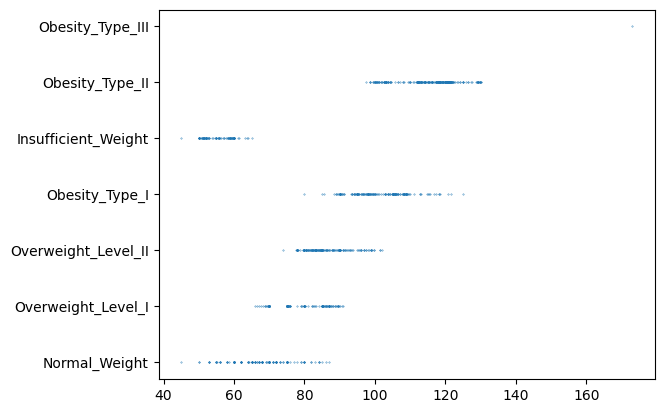

```python
%matplotlib inline
import matplotlib.pyplot as plt
x = data.Peso[data.Sexo == "Male"]
y = data.NivelDeObesidad[data.Sexo == "Male"]
alpha = 0.09
plt.scatter(x,y,alpha)
plt.show()
```

Referencias: [1] E. A. Gutiérrez Cortez, E. D. S. Goicochea Ríos, and Linares Reyes, “Definición de obesidad: más allá del índice de masa corporal,” Revista Médica Vallejiana Vallejian Medical Journal, vol. 9, no. 1, pp. 61–64, Mar. 2020, doi: 10.18050/revistamedicavallejiana.

Firma de honor: "Doy mi palabra que he realizado esta actividad con integridad academica"